# class08

Dominika Kardasz

April 25th, 2019

#K-means clustering

Let’s start with an example of runing **kmeans()** function

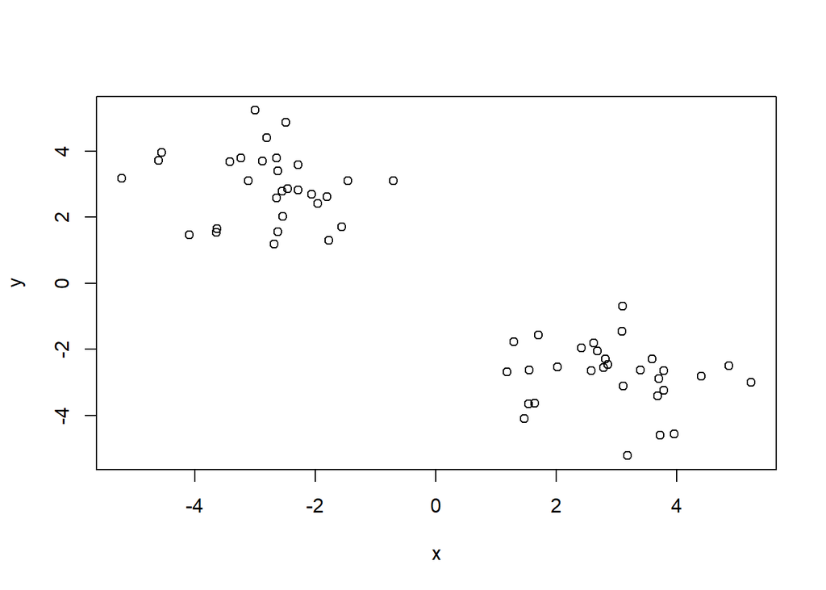

```r
# Generate some example data for clustering- rnorm generates random 30 points, here two groups
tmp <- c(rnorm(30,-3), rnorm(30,3))
x <- cbind(x=tmp, y=rev(tmp))
plot(x)
```

To do : -Use the kmeans() function setting k to 2 and nstart=20 -Inspect/print the results

```r
km <- kmeans(x, centers=2, nstart=20)
km
```

```
## K-means clustering with 2 clusters of sizes 30, 30
##
## Cluster means:
##           x         y
## 1 -2.777519  2.928965
## 2  2.928965 -2.777519
##
## Clustering vector:
##  [1] 1 1 1 1 1 1 1 1 1 1 1 1 1 1 1 1 1 1 1 1 1 1 1 1 1 1 1 1 1 1 2 2 2 2 2
## [36] 2 2 2 2 2 2 2 2 2 2 2 2 2 2 2 2 2 2 2 2 2 2 2 2 2
##
## Within cluster sum of squares by cluster:
## [1] 60.62212 60.62212
##  (between_SS / total_SS =  89.0 %)
##
## Available components:
##
## [1] "cluster"      "centers"      "totss"        "withinss"
## [5] "tot.withinss" "betweenss"    "size"         "iter"
## [9] "ifault"
```

> Q. How many points are in each cluster? A. 30 points in each

> Q. What ‘component’ of your result object details - cluster size?

```r
km$size
```

```
## [1] 30 30
```

- cluster assignment/membership?

```r
km$cluster
```

```
##  [1] 1 1 1 1 1 1 1 1 1 1 1 1 1 1 1 1 1 1 1 1 1 1 1 1 1 1 1 1 1 1 2 2 2 2 2
## [36] 2 2 2 2 2 2 2 2 2 2 2 2 2 2 2 2 2 2 2 2 2 2 2 2 2
```

- cluster center? “centers”

```r
km$centers
```

```
##           x         y
## 1 -2.777519  2.928965
## 2  2.928965 -2.777519
```

> Plot x colored by the kmeans cluster assignment and add cluster centers as blue points

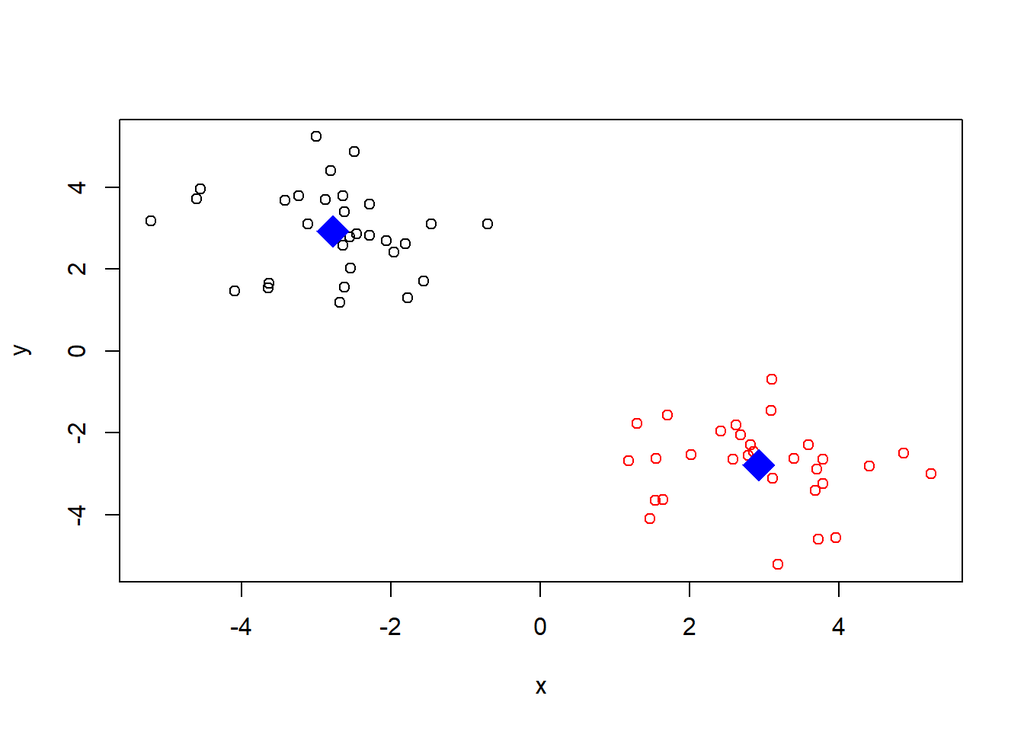

```r
#accesing 1 cluster to colour it
plot(x, col=km$cluster)
# adding the centres of the clusters
points(km$centers, pch=18, col=("blue"), cex=3)
```

##Hierarchical Clustering example

We must give the **hclust()** function a distance matrix not the raw data as input

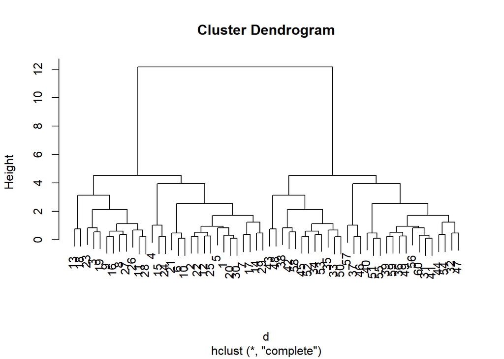

```r
#Distance matrix calculation
d<- dist(x)

#clustering
hc<- hclust(d)

#plot results as a dendrogram
plot(hc)
```

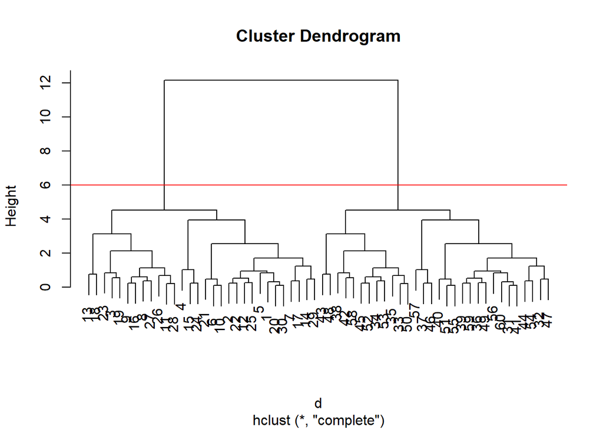

```r
plot(hc)
abline(h=6, col="red")
```

```r
cutree(hc, h=6)
```

```
##  [1] 1 1 1 1 1 1 1 1 1 1 1 1 1 1 1 1 1 1 1 1 1 1 1 1 1 1 1 1 1 1 2 2 2 2 2
## [36] 2 2 2 2 2 2 2 2 2 2 2 2 2 2 2 2 2 2 2 2 2 2 2 2 2
```

```r
cutree(hc, k=2)
```

```
##  [1] 1 1 1 1 1 1 1 1 1 1 1 1 1 1 1 1 1 1 1 1 1 1 1 1 1 1 1 1 1 1 2 2 2 2 2
## [36] 2 2 2 2 2 2 2 2 2 2 2 2 2 2 2 2 2 2 2 2 2 2 2 2 2
```

```r
cutree(hc, k=3)
```

```
##  [1] 1 1 1 1 1 1 1 1 1 1 1 1 1 1 1 1 1 1 1 1 1 1 1 1 1 1 1 1 1 1 2 2 3 3 3
## [36] 2 2 3 2 2 2 3 3 2 3 2 2 3 2 3 2 3 3 2 2 2 2 3 2 2
```

Another example, but more real life like with overlapping clusters of data

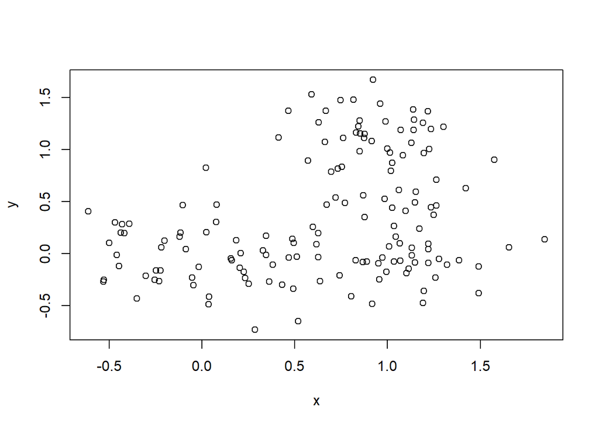

```r
# Step 1. Generate some example data for clustering
x <- rbind(
matrix(rnorm(100, mean=0, sd = 0.3), ncol = 2), # c1
matrix(rnorm(100, mean = 1, sd = 0.3), ncol = 2), # c2
matrix(c(rnorm(50, mean = 1, sd = 0.3), # c3
rnorm(50, mean = 0, sd = 0.3)), ncol = 2))
colnames(x) <- c("x", "y")

# Step 2. Plot the data without clustering
plot(x)
```

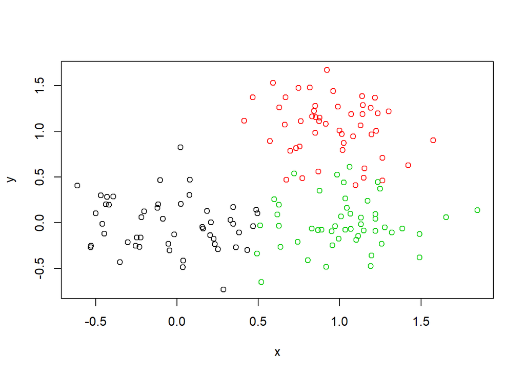

```r
# Step 3. Generate colors for known clusters
# (just so we can compare to hclust results)
col <- as.factor( rep(c("c1","c2","c3"), each=50) )
plot(x, col=col)
```

> Q. Use the dist(), hclust(), plot() and cutree() functions to return 2 and 3 clusters

> Q. How does this compare to your known ‘col’ groups?

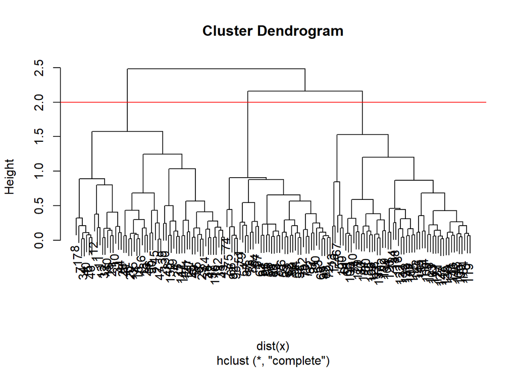

```r
#distance matrix calculation and clustering
hc <- hclust( dist(x))
#plot results as a dendrogram
plot(hc)
abline(h=2, col="red")
abline(h=2.8, col="blue")
```

```r
# give results for 2 and 3 clusters
gp2 <- cutree(hc, k=2)
gp3 <- cutree(hc, k=3)
```

```r
gp2
```

```
##   [1] 1 1 1 1 1 1 1 1 1 1 1 1 1 1 1 1 1 1 1 1 1 1 1 1 1 1 1 1 1 1 1 1 1 1 1
##  [36] 1 1 1 1 1 1 1 1 1 1 1 1 1 1 1 2 2 2 2 2 2 2 2 2 2 2 2 2 2 2 2 2 2 2 2
##  [71] 2 2 2 2 2 2 2 2 2 2 2 2 2 2 2 2 2 2 2 2 2 2 2 2 2 2 2 2 2 2 2 2 2 2 2
## [106] 2 2 2 2 2 2 1 2 2 2 1 2 2 2 2 1 2 2 2 2 2 2 2 2 1 2 2 2 2 2 2 2 2 2 2
## [141] 1 2 2 2 2 2 1 2 2 1
```

```r
gp3
```

```
##   [1] 1 1 1 1 1 1 1 1 1 1 1 1 1 1 1 1 1 1 1 1 1 1 1 1 1 1 1 1 1 1 1 1 1 1 1
##  [36] 1 1 1 1 1 1 1 1 1 1 1 1 1 1 1 2 2 2 2 3 2 2 2 2 3 3 2 2 2 2 2 3 3 2 2
##  [71] 3 2 2 2 2 2 2 2 2 3 2 2 2 2 3 2 2 2 2 2 2 2 3 2 2 2 2 2 2 3 3 3 3 3 3
## [106] 3 3 3 3 3 3 1 3 3 3 1 3 3 3 3 1 3 3 3 3 3 3 3 3 1 3 3 3 3 3 3 3 3 3 3
## [141] 1 3 3 3 3 3 1 3 3 1
```

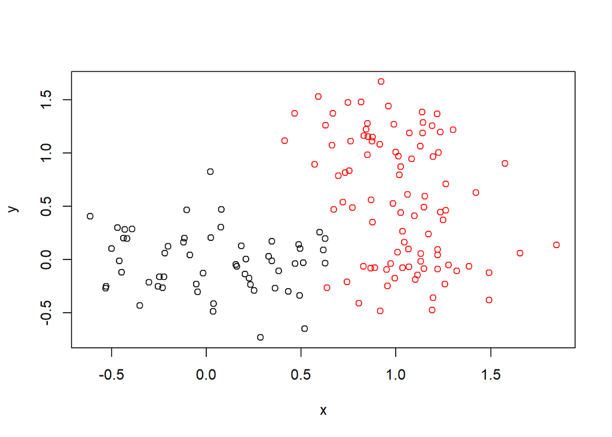

```r
plot(x, col=gp2)
```

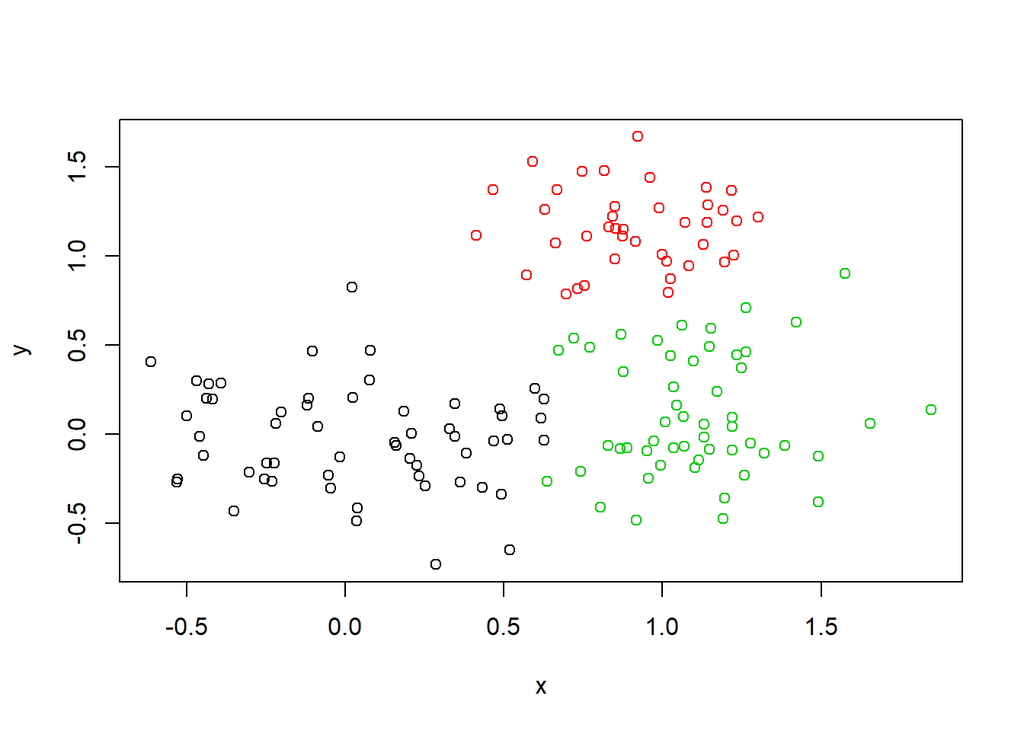

```r
plot(x, col=gp3)
```

```r
table(gp2)
```

```
## gp2
##  1  2
## 57 93
```

```r
table(gp3)
```

```
## gp3
##  1  2  3
## 57 40 53
```

```r
#comparing in a way anwsers from the two different gp's
table(gp2, gp3)
```

```
##    gp3
## gp2  1  2  3
##   1 57  0  0
##   2  0 40 53
```

#PCA: Principal Component Analysis